## Practical Machine Learning Course Project

#### 03/25/2016

### Synopsis

In this project, we will look at the data from accelerometers on the belt, forearm, arm, and dumbell of 6 participants. They were asked to perform barbell lifts correctly and incorrectly in 5 different ways. The goal of the project is to predict the manner in which they did the exercise. The prediction model will be used to predict 20 different test cases. Possible methods include:

- A: exactly according to the specification
- B: throwing the elbows to the front
- C: lifting the dumbbell only halfway
- D: lowering the dumbbell only halfway
- E: throwing the hips to the front

Data source: http://groupware.les.inf.puc-rio.br/har

### Data Pre-processing

```r
## Loading raw data
urltrain <- "https://d396qusza40orc.cloudfront.net/predmachlearn/pml-training.csv"
download.file(urltrain, destfile = "pml-training.csv")
dataTrain <- read.csv("pml-training.csv")
urltest <- "https://d396qusza40orc.cloudfront.net/predmachlearn/pml-testing.csv"
download.file(urltest, destfile = "pml-testing.csv")
dataTest <- read.csv("pml-testing.csv")
dim(dataTrain)
```

```
## [1] 19622   160
```

The training data set consists of total 19,622 observations of 160 variables. First, We will split the data set into training and validation sets with 70% and 30% data split respectively.

```r
library(caret)
set.seed(12321)
inTrain <- createDataPartition(dataTrain$classe,p = 0.7,list = FALSE)
trainSet <- dataTrain[inTrain,]
validSet <- dataTrain[-inTrain,]
```

If we look closely at the summary of the data set, we can notice that some variables contain more than 90% of NA or blank values. Such variables include those that start with *kurtosis*, *skewness*, *max*, *min*, *amplitude*, *var*, *avg*, and *stddev*, as well as variable *cvtd_timestamp*. They cannot be imputed due to few records and will not make significant contribution to the model, therefore we will remove them from the set.

```r
colIndex <- grep("^kurtosis|^skewness|^max_|^min_|^amplitude|^var_|^avg_|^stddev_|^cvtd_timestamp",colnames(trainSet))
trainSet <- trainSet[,-colIndex]
validSet <- validSet[,-colIndex]
```

Now, we will remove variables with near zero variance as they are not expected to have substantial meaning as predictors.

```r
nzv <- nearZeroVar(trainSet)
trainSet <- trainSet[,-nzv]
validSet <- validSet[,-nzv]
```

Finally, we do not expect indices, usernames, or any of the timestamp variables to serve as meaningful predictors, thus we exclude them from the set.

```r
colIndex1 <- grep("^[Xx]$|^user|timestamp",colnames(trainSet))
trainSet <- trainSet[,-colIndex1]
validSet <- validSet[,-colIndex1]
```

Final raw set contains the predicted variable *classe* and 53 potential predictor variables.

### Model Selection

```r
fitControl <- trainControl(method = "cv", number = 10)
## train the random forest model
set.seed(12321)
rfFit <- train(classe ~ ., data = trainSet, method = "rf", trControl = fitControl)
## train the gradient boosting model
set.seed(12321)
gbmFit <- train(classe ~ ., data = trainSet, method = "gbm", trControl = fitControl, verbose = FALSE)
```

The two models are now compared using the *resamples* function.

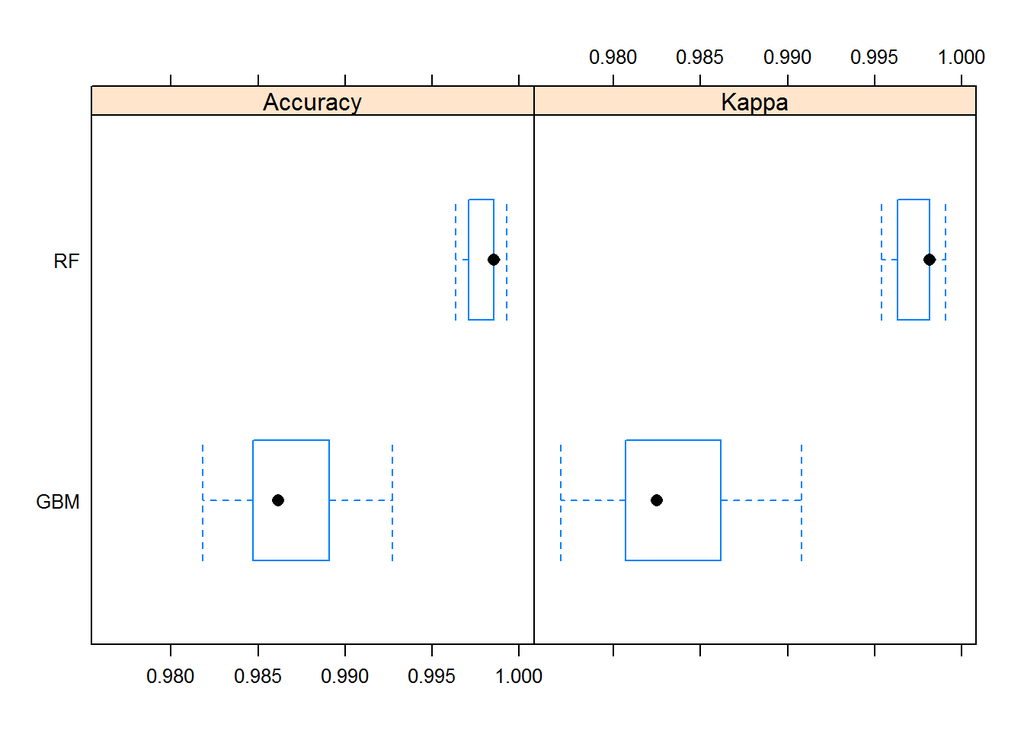

```r
results <- resamples(list(RF = rfFit, GBM = gbmFit))
bwplot(results)
```

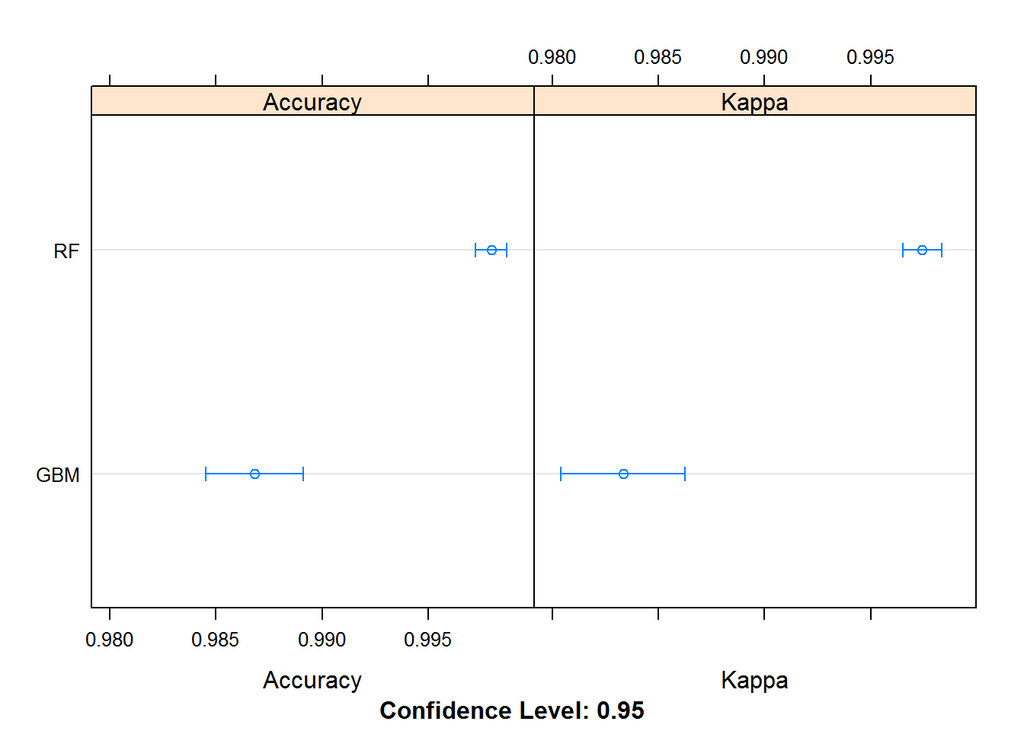

```r
dotplot (results)
```

Box and dot plots indicate that random forest model has higher accuracy and kappa values. It also has a narrower spread than the gradient boost model. Therefore, we choose the random forest model for further analysis.

```r
rfFit$finalModel
```

```
##
## Call:
##  randomForest(x = x, y = y, mtry = param$mtry)
##                Type of random forest: classification
##                      Number of trees: 500
## No. of variables tried at each split: 27
##
##         OOB estimate of  error rate: 0.23%
## Confusion matrix:
##      A    B    C    D    E  class.error
## A 3904    1    0    0    1 0.0005120328
## B    2 2652    3    1    0 0.0022573363
## C    0    7 2389    0    0 0.0029215359
## D    0    0    9 2242    1 0.0044404973
## E    0    0    0    6 2519 0.0023762376
```

Final model includes 500 trees and uses 27 variables at each split. Out-of-sample error is expected to be 0.23%.

### Model Validation

```r
validPreds <- predict(rfFit, newdata = validSet)
confusionMatrix(validSet$classe, validPreds)
```

```
## Confusion Matrix and Statistics
##
##           Reference
## Prediction    A    B    C    D    E
##          A 1674    0    0    0    0
##          B    1 1137    1    0    0
##          C    0    1 1025    0    0
##          D    0    0    1  963    0
##          E    0    0    0    2 1080
##
## Overall Statistics
##
##                Accuracy : 0.999
##                  95% CI : (0.9978, 0.9996)
##     No Information Rate : 0.2846
##     P-Value [Acc > NIR] : < 2.2e-16
##
##                   Kappa : 0.9987
##  Mcnemar's Test P-Value : NA
##
## Statistics by Class:
##
##                      Class: A Class: B Class: C Class: D Class: E
## Sensitivity            0.9994   0.9991   0.9981   0.9979   1.0000
## Specificity            1.0000   0.9996   0.9998   0.9998   0.9996
## Pos Pred Value         1.0000   0.9982   0.9990   0.9990   0.9982
## Neg Pred Value         0.9998   0.9998   0.9996   0.9996   1.0000
## Prevalence             0.2846   0.1934   0.1745   0.1640   0.1835
## Detection Rate         0.2845   0.1932   0.1742   0.1636   0.1835
## Detection Prevalence   0.2845   0.1935   0.1743   0.1638   0.1839
## Balanced Accuracy      0.9997   0.9993   0.9989   0.9989   0.9998
```

According to the matrix the model performs with 99.9% accuracy and kappa value of 0.9987.

### Test Data Predictions

Finally, the random forrest model is used to predict 20 *classe* values for the test data set.

```r
predictions <- predict(rfFit, newdata = dataTest)
print(as.data.frame(predictions))
```

```
##    predictions
## 1            B
## 2            A
## 3            B
## 4            A
## 5            A
## 6            E
## 7            D
## 8            B
## 9            A
## 10           A
## 11           B
## 12           C
## 13           B
## 14           A
## 15           E
## 16           E
## 17           A
## 18           B
## 19           B
## 20           B
```